# Course Project 1

Miguel Barranco

28/11/2020

## Assignment

The information used for this activity was obtained from the course [website](https://d396qusza40orc.cloudfront.net/repdata%2Fdata%2Factivity.zip), as well as instructions. For more information, you can visit [course’s GitHub Repository](https://github.com/rdpeng/RepData_PeerAssessment1).

### Loading and preprocessing the data

Show any code that is needed to:

1. Load the data (i.e. `read.csv()`)

```r
Data <-read.csv("F:/Miguel/PersonalCoding/RProjects/Coursera/Reproducible Research/RepData_PeerAssessment1/activity.csv")
Data
```

| steps | date | interval |
| --- | --- | --- |
| NA | 2012-10-01 | 0 |
| NA | 2012-10-01 | 5 |
| NA | 2012-10-01 | 10 |
| NA | 2012-10-01 | 15 |
| NA | 2012-10-01 | 20 |
| NA | 2012-10-01 | 25 |
| NA | 2012-10-01 | 30 |
| NA | 2012-10-01 | 35 |
| NA | 2012-10-01 | 40 |
| NA | 2012-10-01 | 45 |

[output cut: 9990 more lines]

2. Process/transform the data (if necessary) into a format suitable for your analysis
- Adjusting date type to date for easy separation and later subplotting down the line

```r
library(lubridate)
#Data type set from character to date
Data$date<-ymd(Data$date)
#Identifying weekdays for last question
Weekday <- weekdays(Data$date)
#Adding new col
Data <- cbind(Data,Weekday)
summary(Data)
```

```
##      steps             date               interval        Weekday
##  Min.   :  0.00   Min.   :2012-10-01   Min.   :   0.0   Length:17568
##  1st Qu.:  0.00   1st Qu.:2012-10-16   1st Qu.: 588.8   Class :character
##  Median :  0.00   Median :2012-10-31   Median :1177.5   Mode  :character
##  Mean   : 37.38   Mean   :2012-10-31   Mean   :1177.5
##  3rd Qu.: 12.00   3rd Qu.:2012-11-15   3rd Qu.:1766.2
##  Max.   :806.00   Max.   :2012-11-30   Max.   :2355.0
##  NA's   :2304
```

### What is mean total number of steps taken per day?

For this part of the assignment, you can ignore the missing values in the dataset.

1. Make a histogram of the total number of steps taken each day

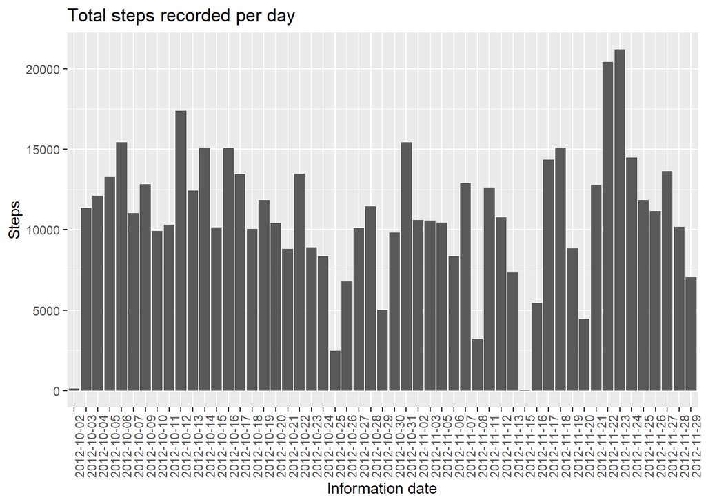

```r
library(ggplot2)
#Calculating steps means based on dates
ResTable<-aggregate(steps~date,Data,sum,na.rm=TRUE)
#Plot generation for means visualization
ggplot( ResTable, aes(factor(date), steps)) +
    geom_col() +
    xlab("Information date") +
    ylab("Steps") +
    ggtitle("Total steps recorded per day") +
    theme(axis.text.x = element_text(angle = 90), legend.position="none")
```

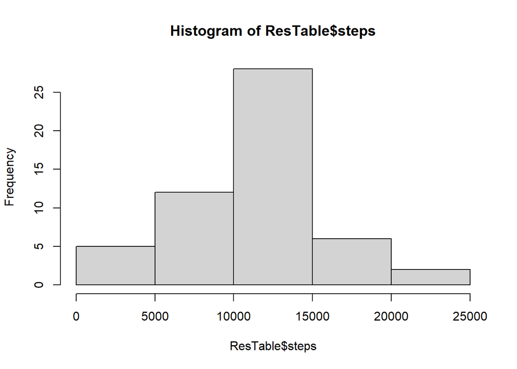

```r
#Simple histogram
hist(ResTable$steps)
```

2. Calculate and report the **mean** and **median** total number of steps taken per day
- Median of total steps per day during experiment:

```r
Med<-median(ResTable$steps)
Med
```

```
## [1] 10765
```

- Mean of total steps per day during experiment:

```r
Mea<-mean(ResTable$steps)
Mea
```

```
## [1] 10766.19
```

### What is the average daily activity pattern?

1. Make a time series plot (i.e. `type = "l"`) of the 5-minute interval (x-axis) and the average number of steps taken, averaged across all days (y-axis)

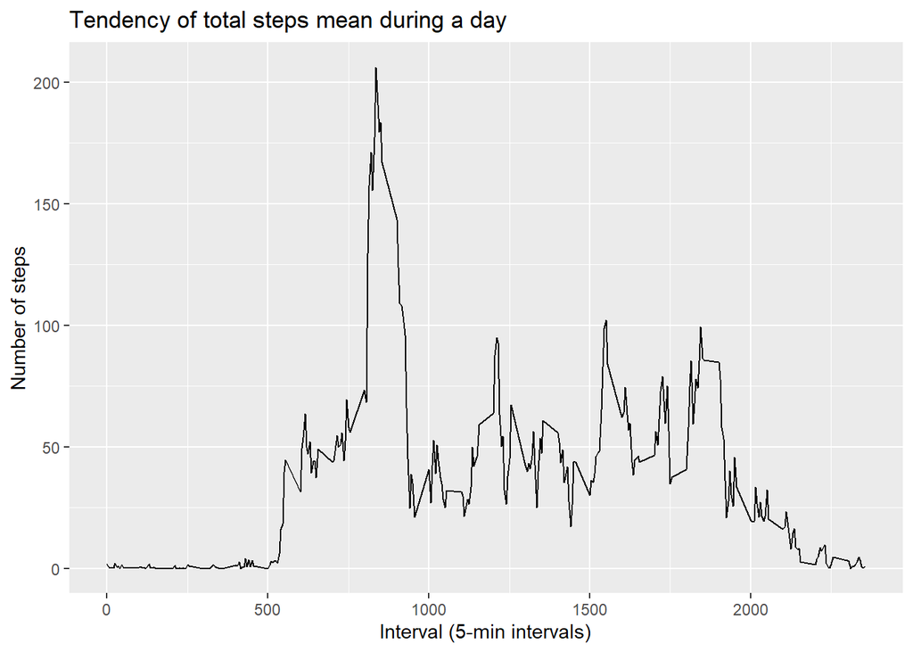

```r
#Calculating steps means based on intervals
TempTable <- aggregate(steps~interval,Data,mean,na.rm=TRUE)
#Plot generation for means visualization
ggplot(TempTable, aes(interval, steps)) +
    geom_line() +
    xlab("Interval (5-min intervals)") +
    ylab("Number of steps") +
    ggtitle("Tendency of total steps mean during a day") +
    theme(legend.position="none")
```

2. Which 5-minute interval, on average across all the days in the dataset, contains the maximum number of steps?

```r
#Identifying maximum value
MaxV<-max(TempTable$steps)
#Identifying interval of maximum value
TempTable[TempTable$steps==MaxV,1]
```

```
## [1] 835
```

### Imputing missing values

Note that there are a number of days/intervals where there are missing values (coded as `NA`). The presence of missing days may introduce bias into some calculations or summaries of the data.

1. Calculate and report the total number of missing values in the dataset (i.e. the total number of rows with `NA`s)

```r
NaCont<-nrow(Data[is.na(Data$steps),])
#Result should correspond to same number on summary from 1st question (2304)
NaCont
```

```
## [1] 2304
```

2. Devise a strategy for filling in all of the missing values in the dataset. The strategy does not need to be sophisticated. For example, you could use the mean/median for that day, or the mean for that 5-minute interval, etc.
- Replacing information based on the mean for interval seems to be rounded enough to avoid influencing the results trend

```r
#Subsetting NAs data
NaTable<-Data[is.na(Data$steps),]
#Replacing NAs for mean values, based on interval matching
NaTable$steps<-TempTable$steps[match(TempTable$interval,NaTable$interval)]
```

3. Create a new dataset that is equal to the original dataset but with the missing data filled in.

```r
#Creating new identical dataset
NewData<-Data
#j variable for controlled pacing on if cycle
j<-1
for (i in 1:nrow(NewData)){
    if (is.na(NewData[i,1])){
        NewData[i,1]<-NaTable[j,1]
        j<-j+1
    }
}
#Sanity check to review for NAs on new dataset
NaCont<-nrow(NewData[is.na(NewData$steps),])
NaCont
```

```
## [1] 0
```

4. Make a histogram of the total number of steps taken each day and Calculate and report the **mean** and **median** total number of steps taken per day. Do these values differ from the estimates from the first part of the assignment? What is the impact of imputing missing data on the estimates of the total daily number of steps?
- Some changes are expected due to the addition of data for 8 previously ignored dates, at least a slight change strengthening a tendency of values approaching the mean.

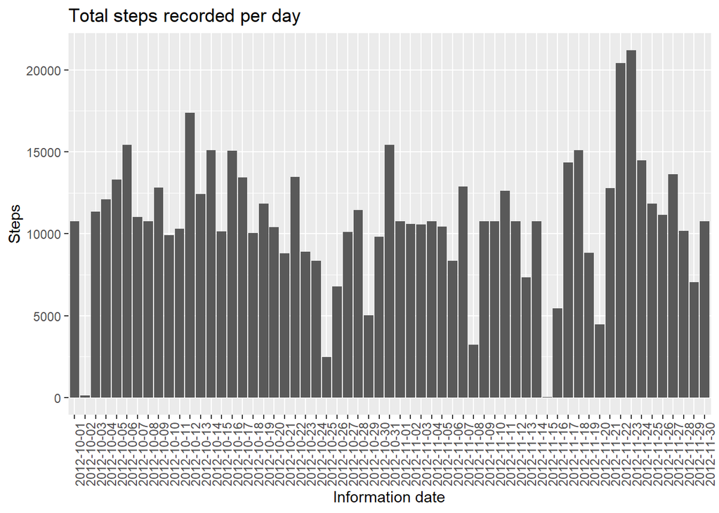

```r
#Calculating steps means based on dates
NewResTable<-aggregate(steps~date,NewData,sum,na.rm=TRUE)
#Plot generation for means visualization
ggplot( NewResTable, aes(factor(date), steps)) +
    geom_col() +
    xlab("Information date") +
    ylab("Steps") +
    ggtitle("Total steps recorded per day") +
    theme(axis.text.x = element_text(angle = 90), legend.position="none")
```

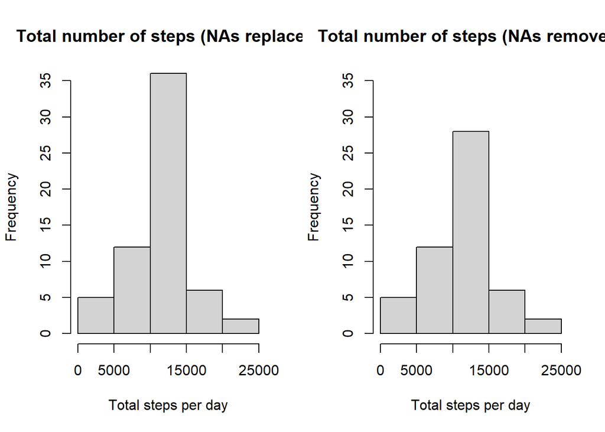

```r
#Simple histogram
par(mfrow=c(1,2))
hist(NewResTable$steps, xlab = "Total steps per day", main = "Total number of steps (NAs replaced)", ylim = c(0,35))
hist(ResTable$steps, xlab = "Total steps per day", main = "Total number of steps (NAs removed)", ylim = c(0,35))
```

```r
#New Median
NMed<-median(NewResTable$steps)
NMed
```

```
## [1] 10766.19
```

```r
#Median comparison
CompMed<-NMed==Med
CompMed
```

```
## [1] FALSE
```

```r
#New Mean
NMea<-mean(NewResTable$steps)
NMea
```

```
## [1] 10766.19
```

```r
#Mean comparison
CompMea<-NMea==Mea
CompMea
```

```
## [1] TRUE
```

### Are there differences in activity patterns between weekdays and weekends?

For this part the `weekdays()` function may be of some help here. Use the dataset with the filled-in missing values for this part.

1. Create a new factor variable in the dataset with two levels – “weekday” and “weekend” indicating whether a given date is a weekday or weekend day.

```r
#Creating new column
NewData$WeekdayType<-c(NA)
#Assigning levels
for (i in 1:nrow(NewData)){
    if (NewData[i,4]=="sábado"|NewData[i,4]=="domingo"){
        NewData[i,5]<-"Weekend"
    } else {
        NewData[i,5]<-"Weekday"
    }
}
```

1. Make a panel plot containing a time series plot (i.e. `type = "l"`) of the 5-minute interval (x-axis) and the average number of steps taken, averaged across all weekday days or weekend days (y-axis).

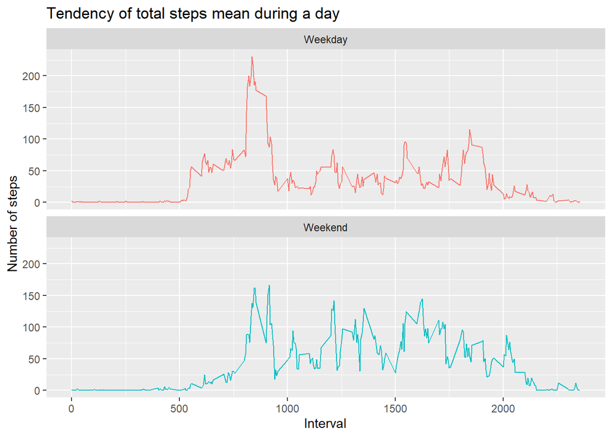

```r
#Calculating steps means based on intervals
TempTable <- aggregate(steps~interval + WeekdayType,NewData,mean)
#Plot generation for means visualization
ggplot(TempTable, aes(interval, steps, color=WeekdayType)) +
    geom_line() +
    xlab("Interval") +
    ylab("Number of steps") +
    ggtitle("Tendency of total steps mean during a day") +
    facet_wrap(~WeekdayType, ncol = 1, nrow=2) +
    theme(legend.position="none")
```